# Module 94

#### Contrast SVE:

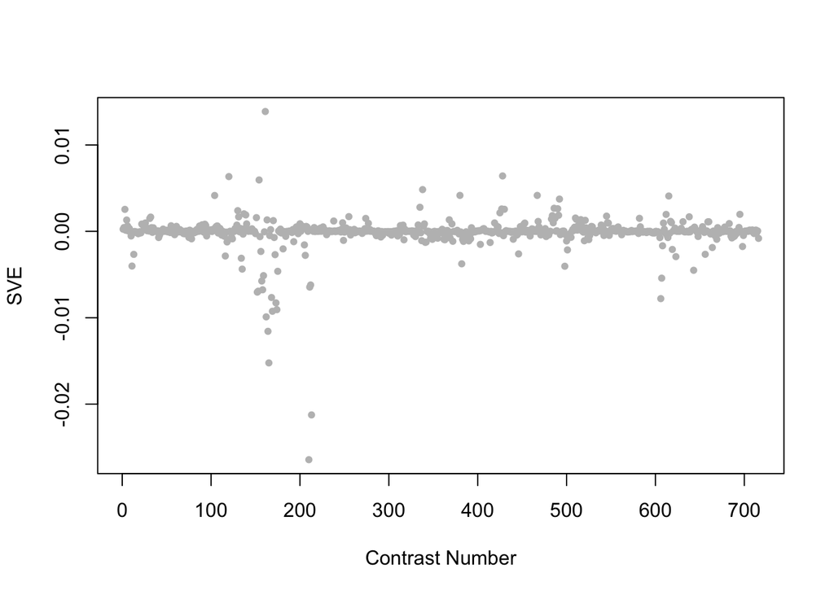

Positive SVE Contrasts:

|  | Contrast.Num | SVE | GEO.GSE | Cond.1 | Cond.2 | Mutation |
| --- | --- | --- | --- | --- | --- | --- |
| GSE47778.s4t2.vs.s3t2 | 161 | 0.01 | GSE47778 | daf-2;daf-16; starvation; replicate 1 | daf-16; starvation; replicate 1 | daf-2;daf-16 vs. daf-16 |
| GSE27677A.s3t1.vs.s0t1 | 428 | 0.01 | GSE27677 | daf-16, Fed , rep 1 | N2, Fed , rep 1 | daf-16 |
| GSE54024.s3t1.vs.s4t1 | 120 | 0.01 | GSE54024 | nuo-6(qm200) young adults, biological rep 1 | isp-1(qm150) young adults, biological rep 1 |  |
| GSE47778.s4t1.vs.s2t1 | 154 | 0.01 | GSE47778 | daf-2;daf-16; replicate 1 | daf-2; replicate 1 | daf-2;daf-16 vs. daf-2 |
| GSE38997.s2t1.vs.s1t1 | 338 | 0.00 | GSE38997 | experiment 4 EtBr-exposed samples at 3 h 4e3 | experiment 4 control samples at 3 h 4c3 |  |

Negative SVE Contrasts:

|  | Contrast.Num | SVE | GEO.GSE | Cond.1 | Cond.2 | Mutation |
| --- | --- | --- | --- | --- | --- | --- |
| GSE42689.s3t1.vs.s1t1 | 210 | -0.03 | GSE42689 | mlk-1 fasted 1 | mek-1 fasted 1 |  |
| GSE42689.s4t1.vs.s2t1 | 213 | -0.02 | GSE42689 | mlk-1 fed 1 | mek-1 fed 1 |  |
| GSE47778.s1t2.vs.s4t2 | 165 | -0.02 | GSE47778 | N2; starvation; replicate 1 | daf-2;daf-16; starvation; replicate 1 | daf-2;daf-16 |
| GSE47778.s1t2.vs.s2t2 | 164 | -0.01 | GSE47778 | N2; starvation; replicate 1 | daf-2; starvation; replicate 1 | daf-2 |
| GSE47778.s1t2.vs.s3t2 | 162 | -0.01 | GSE47778 | N2; starvation; replicate 1 | daf-16; starvation; replicate 1 | daf-16 |

$~$

#### Contrast SVE, Up-Regulated Genes Only:

Calculating SVE for up-regulated and down-regulated genes separately may be more informative in many cases than projecting the up- and down- gene sets together. This is due to the fact that the weight distribution of many modules is highly skewed, indicating that only one of the hemi-modules may be biologically meaningful (i.e., a set of genes are strongly correlated by only a few genes (or none) are strongly anti-correlated to that set.)

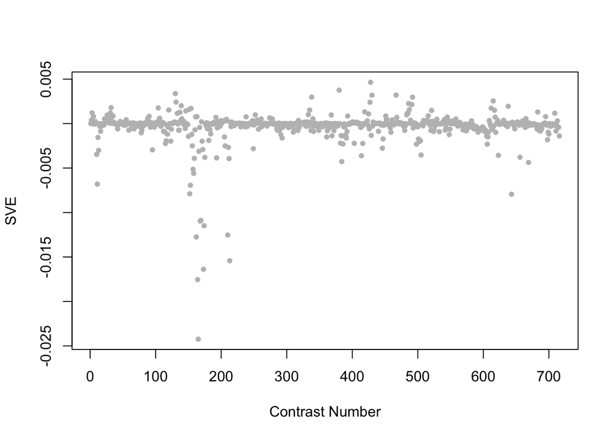

Positive SVE Contrasts:

|  | Contrast.Num | SVE | GEO.GSE | Cond.1 | Cond.2 | Mutation |
| --- | --- | --- | --- | --- | --- | --- |
| GSE27677A.s3t1.vs.s0t1 | 428 | 0.00 | GSE27677 | daf-16, Fed , rep 1 | N2, Fed , rep 1 | daf-16 |
| GSE34471.s1t1.vs.s0t1 | 380 | 0.00 | GSE34471 | 4uM-Exp1 | 4uM-Con-1 | hrg-2 |
| GSE52064.s4t1.vs.s3t1 | 130 | 0.00 | GSE52064 | lin-54;mes-4_1 | lin-54_1 | mes-4 |
| GSE23528A.s1t1.vs.s0t1 | 467 | 0.00 | GSE23528 | Adult at T2 in LD, time-series experiment 3 | Adult at T2, non-entrained control time-series experiment 4 |  |
| GSE27677A.s1t1.vs.s0t1 | 430 | 0.00 | GSE27677 | kgb-1, Fed , rep 1 | N2, Fed , rep 1 | kgb-1 |

Negative SVE Contrasts:

|  | Contrast.Num | SVE | GEO.GSE | Cond.1 | Cond.2 | Mutation |
| --- | --- | --- | --- | --- | --- | --- |
| GSE47778.s1t2.vs.s4t2 | 165 | -0.02 | GSE47778 | N2; starvation; replicate 1 | daf-2;daf-16; starvation; replicate 1 | daf-2;daf-16 |
| GSE47778.s1t2.vs.s2t2 | 164 | -0.02 | GSE47778 | N2; starvation; replicate 1 | daf-2; starvation; replicate 1 | daf-2 |
| GSE47778.s1t3.vs.s4t3 | 173 | -0.02 | GSE47778 | N2; UV; replicate 1 | daf-2;daf-16; UV; replicate 1 | daf-2;daf-16 |
| GSE42689.s4t1.vs.s2t1 | 213 | -0.02 | GSE42689 | mlk-1 fed 1 | mek-1 fed 1 |  |
| GSE47778.s1t2.vs.s3t2 | 162 | -0.01 | GSE47778 | N2; starvation; replicate 1 | daf-16; starvation; replicate 1 | daf-16 |

$~$

#### Contrast SVE, Down-Regulated Genes Only:

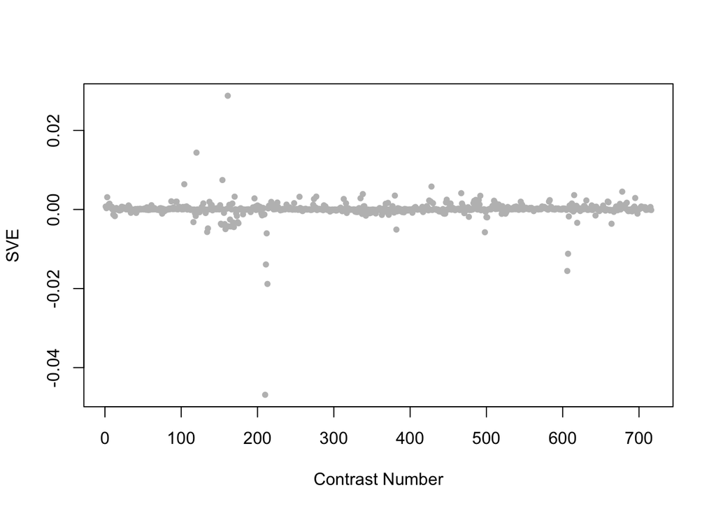

Positive SVE Contrasts:

|  | Contrast.Num | SVE | GEO.GSE | Cond.1 | Cond.2 | Mutation |
| --- | --- | --- | --- | --- | --- | --- |
| GSE47778.s4t2.vs.s3t2 | 161 | 0.03 | GSE47778 | daf-2;daf-16; starvation; replicate 1 | daf-16; starvation; replicate 1 | daf-2;daf-16 vs. daf-16 |
| GSE54024.s3t1.vs.s4t1 | 120 | 0.01 | GSE54024 | nuo-6(qm200) young adults, biological rep 1 | isp-1(qm150) young adults, biological rep 1 |  |
| GSE47778.s4t1.vs.s2t1 | 154 | 0.01 | GSE47778 | daf-2;daf-16; replicate 1 | daf-2; replicate 1 | daf-2;daf-16 vs. daf-2 |
| GSE57664.s1t1.vs.s0t1 | 104 | 0.01 | GSE57664 | TYR treated rep1 | control rep1 |  |
| GSE27677A.s3t1.vs.s0t1 | 428 | 0.01 | GSE27677 | daf-16, Fed , rep 1 | N2, Fed , rep 1 | daf-16 |

Negative SVE Contrasts:

|  | Contrast.Num | SVE | GEO.GSE | Cond.1 | Cond.2 | Mutation |
| --- | --- | --- | --- | --- | --- | --- |
| GSE42689.s3t1.vs.s1t1 | 210 | -0.05 | GSE42689 | mlk-1 fasted 1 | mek-1 fasted 1 |  |
| GSE42689.s4t1.vs.s2t1 | 213 | -0.02 | GSE42689 | mlk-1 fed 1 | mek-1 fed 1 |  |
| GSE21784.s1t1.vs.s3t1 | 606 | -0.02 | GSE21784 | L4 larvae, biological rep1 | day 15 adults, biological rep 1 |  |
| GSE42689.s4t1.vs.s1t1 | 211 | -0.01 | GSE42689 | mlk-1 fed 1 | mek-1 fasted 1 |  |
| GSE21784.s1t1.vs.s2t1 | 607 | -0.01 | GSE21784 | L4 larvae, biological rep1 | day 6 adults, biological rep 1 |  |

$~$

$~$

#### GO Term Enrichment:

This analysis tests each hemi-module for enrichment of specific GO terms. Only gene-level annotations (e.g., as would be found on the gene’s page in Wormbase) are tested - the hierarchical structure of the GO ontology is not taken into account.

*Note: At least the top two most enriched terms from each GO domain (BP/MF/CC) are shown, even when not statistically significant.*

##### Enriched GO terms: Hemi-module A

| ID | GO.Term | GO Domain | Raw p-value | Adj p-value |
| --- | --- | --- | --- | --- |
| [GO_0019934](http://amigo.geneontology.org/amigo/term/GO:0019934) | cGMP-mediated signaling | BP | 5.93e-04 | 9.98e-01 |
| [GO_0006515](http://amigo.geneontology.org/amigo/term/GO:0006515) | protein quality control for misfolded or incompletely synthesized proteins | BP | 2.16e-03 | 9.98e-01 |
| [GO_0000224](http://amigo.geneontology.org/amigo/term/GO:0000224) | peptide-N4-(N-acetyl-beta-glucosaminyl)asparagine amidase activity | MF | 1.26e-03 | 1.00e+00 |
| [GO_0008887](http://amigo.geneontology.org/amigo/term/GO:0008887) | glycerate kinase activity | MF | 5.40e-03 | 1.00e+00 |
| [GO_0016020](http://amigo.geneontology.org/amigo/term/GO:0016020) | membrane | CC | 6.65e-04 | 3.97e-01 |
| [GO_0016021](http://amigo.geneontology.org/amigo/term/GO:0016021) | integral component of membrane | CC | 8.56e-04 | 3.97e-01 |

##### Enriched GO terms: Hemi-module B

| ID | GO.Term | GO Domain | Raw p-value | Adj p-value |
| --- | --- | --- | --- | --- |
| [GO_0000165](http://amigo.geneontology.org/amigo/term/GO:0000165) | MAPK cascade | BP | 1.85e-04 | 3.36e-01 |
| [GO_0023014](http://amigo.geneontology.org/amigo/term/GO:0023014) | signal transduction by protein phosphorylation | BP | 1.85e-04 | 3.36e-01 |
| [GO_0004046](http://amigo.geneontology.org/amigo/term/GO:0004046) | aminoacylase activity | MF | 1.09e-04 | 2.23e-01 |
| [GO_0008545](http://amigo.geneontology.org/amigo/term/GO:0008545) | JUN kinase kinase activity | MF | 2.72e-04 | 2.78e-01 |
| [GO_0031499](http://amigo.geneontology.org/amigo/term/GO:0031499) | TRAMP complex | CC | 4.32e-03 | 1.00e+00 |
| [GO_0031251](http://amigo.geneontology.org/amigo/term/GO:0031251) | PAN complex | CC | 8.63e-03 | 1.00e+00 |

$~$

$~$

#### Tissue Enrichment:

This analysis tests each hemi-module for enrichment of genes associated with anatomy terms. Negative enrichment scores indicate fewer hemi-module genes than expected by random chance were associated with the anatomy term in question.

##### Enriched tissues: Hemi-module A

No significant annotations.

##### Enriched tissues: Hemi-module B

No significant annotations.

$~$

$~$

#### HOMER promoter motif enrichment:

This analysis tests each hemi-module for enrichment of 108 known *C. elegans* transcription factor binding site motifs (see [108 CE motifs](https://katiepod.github.io//all.worm.motifs.html)) using the HOMER (Hypergeometric Optimization of Motif EnRichment) software (see [PMID:20513432](https://pubmed.ncbi.nlm.nih.gov/20513432)). HOMER was run using default parameters on sequences 1 kb upstream of the transcription start site.

##### Motif enrichment: Hemi-module A

Total target sequences = 95  
Total background sequences = 40453  
* - possible false positive

Rank

Motif

P-value

log P-pvalue

% of Targets

% of Background

STD(Bg STD)

Best Match/Details

Motif File

1 *

[figure not shown]

1e-10

-2.472e+01

6.32%

0.05%

269.5bp (241.6bp)

vab-7/MA0927.1/Jaspar(0.608)  
[More Information](https://katiepod.github.io/HomerResults/m94_a_hemi_genes.txt.out.1kb/homerResults/motif1.info.html) | [Similar Motifs Found](https://katiepod.github.io/HomerResults/m94_a_hemi_genes.txt.out.1kb/homerResults/motif1.similar.html)

[motif file (matrix)](https://katiepod.github.io/HomerResults/m94_a_hemi_genes.txt.out.1kb/homerResults/motif1.motif)

2 *

[figure not shown]

1e-10

-2.428e+01

7.37%

0.11%

348.0bp (267.9bp)

POL010.1_DCE_S_III/Jaspar(0.548)  
[More Information](https://katiepod.github.io/HomerResults/m94_a_hemi_genes.txt.out.1kb/homerResults/motif2.info.html) | [Similar Motifs Found](https://katiepod.github.io/HomerResults/m94_a_hemi_genes.txt.out.1kb/homerResults/motif2.similar.html)

[motif file (matrix)](https://katiepod.github.io/HomerResults/m94_a_hemi_genes.txt.out.1kb/homerResults/motif2.motif)

3 *

[figure not shown]

1e-10

-2.343e+01

22.11%

3.80%

277.9bp (298.0bp)

ceh-48/MA0921.1/Jaspar(0.556)  
[More Information](https://katiepod.github.io/HomerResults/m94_a_hemi_genes.txt.out.1kb/homerResults/motif3.info.html) | [Similar Motifs Found](https://katiepod.github.io/HomerResults/m94_a_hemi_genes.txt.out.1kb/homerResults/motif3.similar.html)

[motif file (matrix)](https://katiepod.github.io/HomerResults/m94_a_hemi_genes.txt.out.1kb/homerResults/motif3.motif)

4 *

[figure not shown]

1e-9

-2.271e+01

9.47%

0.37%

249.1bp (295.1bp)

pqm-1/MA1703.1/Jaspar(0.707)  
[More Information](https://katiepod.github.io/HomerResults/m94_a_hemi_genes.txt.out.1kb/homerResults/motif4.info.html) | [Similar Motifs Found](https://katiepod.github.io/HomerResults/m94_a_hemi_genes.txt.out.1kb/homerResults/motif4.similar.html)

[motif file (matrix)](https://katiepod.github.io/HomerResults/m94_a_hemi_genes.txt.out.1kb/homerResults/motif4.motif)

5 *

[figure not shown]

1e-9

-2.158e+01

14.74%

1.58%

327.7bp (295.4bp)

fkh-9/MA1440.1/Jaspar(0.710)  
[More Information](https://katiepod.github.io/HomerResults/m94_a_hemi_genes.txt.out.1kb/homerResults/motif5.info.html) | [Similar Motifs Found](https://katiepod.github.io/HomerResults/m94_a_hemi_genes.txt.out.1kb/homerResults/motif5.similar.html)

[motif file (matrix)](https://katiepod.github.io/HomerResults/m94_a_hemi_genes.txt.out.1kb/homerResults/motif5.motif)

6 *

[figure not shown]

1e-9

-2.124e+01

10.53%

0.62%

363.3bp (290.9bp)

hlh-30/MA1449.1/Jaspar(0.692)  
[More Information](https://katiepod.github.io/HomerResults/m94_a_hemi_genes.txt.out.1kb/homerResults/motif6.info.html) | [Similar Motifs Found](https://katiepod.github.io/HomerResults/m94_a_hemi_genes.txt.out.1kb/homerResults/motif6.similar.html)

[motif file (matrix)](https://katiepod.github.io/HomerResults/m94_a_hemi_genes.txt.out.1kb/homerResults/motif6.motif)

7 *

[figure not shown]

1e-8

-2.066e+01

6.32%

0.10%

325.8bp (302.1bp)

LIN-39(Homeobox)/cElegans.L3-LIN39-ChIP-Seq(modEncode)/Homer(0.816)  
[More Information](https://katiepod.github.io/HomerResults/m94_a_hemi_genes.txt.out.1kb/homerResults/motif7.info.html) | [Similar Motifs Found](https://katiepod.github.io/HomerResults/m94_a_hemi_genes.txt.out.1kb/homerResults/motif7.similar.html)

[motif file (matrix)](https://katiepod.github.io/HomerResults/m94_a_hemi_genes.txt.out.1kb/homerResults/motif7.motif)

8 *

[figure not shown]

1e-8

-1.872e+01

9.47%

0.59%

245.8bp (285.7bp)

eor-1/MA0543.1/Jaspar(0.558)  
[More Information](https://katiepod.github.io/HomerResults/m94_a_hemi_genes.txt.out.1kb/homerResults/motif8.info.html) | [Similar Motifs Found](https://katiepod.github.io/HomerResults/m94_a_hemi_genes.txt.out.1kb/homerResults/motif8.similar.html)

[motif file (matrix)](https://katiepod.github.io/HomerResults/m94_a_hemi_genes.txt.out.1kb/homerResults/motif8.motif)

9 *

[figure not shown]

1e-7

-1.649e+01

7.37%

0.35%

241.9bp (270.5bp)

POL006.1_BREu/Jaspar(0.640)  
[More Information](https://katiepod.github.io/HomerResults/m94_a_hemi_genes.txt.out.1kb/homerResults/motif9.info.html) | [Similar Motifs Found](https://katiepod.github.io/HomerResults/m94_a_hemi_genes.txt.out.1kb/homerResults/motif9.similar.html)

[motif file (matrix)](https://katiepod.github.io/HomerResults/m94_a_hemi_genes.txt.out.1kb/homerResults/motif9.motif)

10 *

[figure not shown]

1e-6

-1.484e+01

6.32%

0.28%

335.1bp (304.5bp)

efl-1/MA0541.1/Jaspar(0.484)  
[More Information](https://katiepod.github.io/HomerResults/m94_a_hemi_genes.txt.out.1kb/homerResults/motif10.info.html) | [Similar Motifs Found](https://katiepod.github.io/HomerResults/m94_a_hemi_genes.txt.out.1kb/homerResults/motif10.similar.html)

[motif file (matrix)](https://katiepod.github.io/HomerResults/m94_a_hemi_genes.txt.out.1kb/homerResults/motif10.motif)

11 *

[figure not shown]

1e-6

-1.441e+01

11.58%

1.64%

288.1bp (293.2bp)

sma-4/MA0925.1/Jaspar(0.515)  
[More Information](https://katiepod.github.io/HomerResults/m94_a_hemi_genes.txt.out.1kb/homerResults/motif11.info.html) | [Similar Motifs Found](https://katiepod.github.io/HomerResults/m94_a_hemi_genes.txt.out.1kb/homerResults/motif11.similar.html)

[motif file (matrix)](https://katiepod.github.io/HomerResults/m94_a_hemi_genes.txt.out.1kb/homerResults/motif11.motif)

12 *

[figure not shown]

1e-6

-1.418e+01

25.26%

8.32%

231.6bp (289.7bp)

lin-14/MA0261.1/Jaspar(0.680)  
[More Information](https://katiepod.github.io/HomerResults/m94_a_hemi_genes.txt.out.1kb/homerResults/motif12.info.html) | [Similar Motifs Found](https://katiepod.github.io/HomerResults/m94_a_hemi_genes.txt.out.1kb/homerResults/motif12.similar.html)

[motif file (matrix)](https://katiepod.github.io/HomerResults/m94_a_hemi_genes.txt.out.1kb/homerResults/motif12.motif)

13 *

[figure not shown]

1e-5

-1.288e+01

9.47%

1.20%

286.0bp (287.8bp)

POL004.1_CCAAT-box/Jaspar(0.616)  
[More Information](https://katiepod.github.io/HomerResults/m94_a_hemi_genes.txt.out.1kb/homerResults/motif13.info.html) | [Similar Motifs Found](https://katiepod.github.io/HomerResults/m94_a_hemi_genes.txt.out.1kb/homerResults/motif13.similar.html)

[motif file (matrix)](https://katiepod.github.io/HomerResults/m94_a_hemi_genes.txt.out.1kb/homerResults/motif13.motif)

14 *

[figure not shown]

1e-5

-1.168e+01

22.11%

7.64%

284.4bp (298.5bp)

MF0004.1_Nuclear_Receptor_class/Jaspar(0.794)  
[More Information](https://katiepod.github.io/HomerResults/m94_a_hemi_genes.txt.out.1kb/homerResults/motif14.info.html) | [Similar Motifs Found](https://katiepod.github.io/HomerResults/m94_a_hemi_genes.txt.out.1kb/homerResults/motif14.similar.html)

[motif file (matrix)](https://katiepod.github.io/HomerResults/m94_a_hemi_genes.txt.out.1kb/homerResults/motif14.motif)

15 *

[figure not shown]

1e-4

-1.136e+01

22.11%

7.80%

268.2bp (288.6bp)

mab-5/MA1442.1/Jaspar(0.601)  
[More Information](https://katiepod.github.io/HomerResults/m94_a_hemi_genes.txt.out.1kb/homerResults/motif15.info.html) | [Similar Motifs Found](https://katiepod.github.io/HomerResults/m94_a_hemi_genes.txt.out.1kb/homerResults/motif15.similar.html)

[motif file (matrix)](https://katiepod.github.io/HomerResults/m94_a_hemi_genes.txt.out.1kb/homerResults/motif15.motif)

16 *

[figure not shown]

1e-4

-1.111e+01

22.11%

7.93%

215.0bp (311.9bp)

MF0001.1_ETS_class/Jaspar(0.668)  
[More Information](https://katiepod.github.io/HomerResults/m94_a_hemi_genes.txt.out.1kb/homerResults/motif16.info.html) | [Similar Motifs Found](https://katiepod.github.io/HomerResults/m94_a_hemi_genes.txt.out.1kb/homerResults/motif16.similar.html)

[motif file (matrix)](https://katiepod.github.io/HomerResults/m94_a_hemi_genes.txt.out.1kb/homerResults/motif16.motif)

17 *

[figure not shown]

1e-4

-1.089e+01

5.26%

0.33%

278.4bp (259.8bp)

POL012.1_TATA-Box/Jaspar(0.558)  
[More Information](https://katiepod.github.io/HomerResults/m94_a_hemi_genes.txt.out.1kb/homerResults/motif17.info.html) | [Similar Motifs Found](https://katiepod.github.io/HomerResults/m94_a_hemi_genes.txt.out.1kb/homerResults/motif17.similar.html)

[motif file (matrix)](https://katiepod.github.io/HomerResults/m94_a_hemi_genes.txt.out.1kb/homerResults/motif17.motif)

18 *

[figure not shown]

1e-4

-1.031e+01

6.32%

0.62%

253.3bp (277.7bp)

PL0012.1_hlh-2::hlh-8/Jaspar(0.556)  
[More Information](https://katiepod.github.io/HomerResults/m94_a_hemi_genes.txt.out.1kb/homerResults/motif18.info.html) | [Similar Motifs Found](https://katiepod.github.io/HomerResults/m94_a_hemi_genes.txt.out.1kb/homerResults/motif18.similar.html)

[motif file (matrix)](https://katiepod.github.io/HomerResults/m94_a_hemi_genes.txt.out.1kb/homerResults/motif18.motif)

19 *

[figure not shown]

1e-4

-9.384e+00

3.16%

0.08%

183.3bp (307.4bp)

lin-14/MA0261.1/Jaspar(0.553)  
[More Information](https://katiepod.github.io/HomerResults/m94_a_hemi_genes.txt.out.1kb/homerResults/motif19.info.html) | [Similar Motifs Found](https://katiepod.github.io/HomerResults/m94_a_hemi_genes.txt.out.1kb/homerResults/motif19.similar.html)

[motif file (matrix)](https://katiepod.github.io/HomerResults/m94_a_hemi_genes.txt.out.1kb/homerResults/motif19.motif)

20 *

[figure not shown]

1e-3

-8.175e+00

15.79%

5.64%

257.5bp (297.8bp)

MF0011.1_HMG_class/Jaspar(0.615)  
[More Information](https://katiepod.github.io/HomerResults/m94_a_hemi_genes.txt.out.1kb/homerResults/motif20.info.html) | [Similar Motifs Found](https://katiepod.github.io/HomerResults/m94_a_hemi_genes.txt.out.1kb/homerResults/motif20.similar.html)

[motif file (matrix)](https://katiepod.github.io/HomerResults/m94_a_hemi_genes.txt.out.1kb/homerResults/motif20.motif)

21 *

[figure not shown]

1e-3

-7.322e+00

3.16%

0.17%

178.0bp (302.6bp)

POL004.1_CCAAT-box/Jaspar(0.672)  
[More Information](https://katiepod.github.io/HomerResults/m94_a_hemi_genes.txt.out.1kb/homerResults/motif21.info.html) | [Similar Motifs Found](https://katiepod.github.io/HomerResults/m94_a_hemi_genes.txt.out.1kb/homerResults/motif21.similar.html)

[motif file (matrix)](https://katiepod.github.io/HomerResults/m94_a_hemi_genes.txt.out.1kb/homerResults/motif21.motif)

22 *

[figure not shown]

1e-3

-7.234e+00

2.11%

0.04%

174.7bp (247.4bp)

lin-54/MA1450.1/Jaspar(0.658)  
[More Information](https://katiepod.github.io/HomerResults/m94_a_hemi_genes.txt.out.1kb/homerResults/motif22.info.html) | [Similar Motifs Found](https://katiepod.github.io/HomerResults/m94_a_hemi_genes.txt.out.1kb/homerResults/motif22.similar.html)

[motif file (matrix)](https://katiepod.github.io/HomerResults/m94_a_hemi_genes.txt.out.1kb/homerResults/motif22.motif)

23 *

[figure not shown]

1e-2

-6.823e+00

5.26%

0.80%

224.8bp (289.8bp)

lin-14/MA0261.1/Jaspar(0.674)  
[More Information](https://katiepod.github.io/HomerResults/m94_a_hemi_genes.txt.out.1kb/homerResults/motif23.info.html) | [Similar Motifs Found](https://katiepod.github.io/HomerResults/m94_a_hemi_genes.txt.out.1kb/homerResults/motif23.similar.html)

[motif file (matrix)](https://katiepod.github.io/HomerResults/m94_a_hemi_genes.txt.out.1kb/homerResults/motif23.motif)

24 *

[figure not shown]

1e-2

-6.600e+00

4.21%

0.49%

260.9bp (291.7bp)

PL0012.1_hlh-2::hlh-8/Jaspar(0.604)  
[More Information](https://katiepod.github.io/HomerResults/m94_a_hemi_genes.txt.out.1kb/homerResults/motif24.info.html) | [Similar Motifs Found](https://katiepod.github.io/HomerResults/m94_a_hemi_genes.txt.out.1kb/homerResults/motif24.similar.html)

[motif file (matrix)](https://katiepod.github.io/HomerResults/m94_a_hemi_genes.txt.out.1kb/homerResults/motif24.motif)

25 *

[figure not shown]

1e-2

-6.056e+00

1.05%

0.00%

46.2bp (0.0bp)

PL0018.1_hlh-25/Jaspar(0.606)  
[More Information](https://katiepod.github.io/HomerResults/m94_a_hemi_genes.txt.out.1kb/homerResults/motif25.info.html) | [Similar Motifs Found](https://katiepod.github.io/HomerResults/m94_a_hemi_genes.txt.out.1kb/homerResults/motif25.similar.html)

[motif file (matrix)](https://katiepod.github.io/HomerResults/m94_a_hemi_genes.txt.out.1kb/homerResults/motif25.motif)

##### Motif enrichment: Hemi-module B

Total target sequences = 57  
Total background sequences = 39139  
* - possible false positive

Rank

Motif

P-value

log P-pvalue

% of Targets

% of Background

STD(Bg STD)

Best Match/Details

Motif File

1 *

[figure not shown]

1e-9

-2.161e+01

21.05%

1.80%

219.0bp (315.0bp)

PL0017.1_hlh-2::hlh-10/Jaspar(0.574)  
[More Information](https://katiepod.github.io/HomerResults/m94_b_hemi_genes.txt.out.1kb/homerResults/motif1.info.html) | [Similar Motifs Found](https://katiepod.github.io/HomerResults/m94_b_hemi_genes.txt.out.1kb/homerResults/motif1.similar.html)

[motif file (matrix)](https://katiepod.github.io/HomerResults/m94_b_hemi_genes.txt.out.1kb/homerResults/motif1.motif)

2 *

[figure not shown]

1e-8

-2.044e+01

26.32%

3.62%

319.3bp (337.0bp)

eor-1/MA0543.1/Jaspar(0.693)  
[More Information](https://katiepod.github.io/HomerResults/m94_b_hemi_genes.txt.out.1kb/homerResults/motif2.info.html) | [Similar Motifs Found](https://katiepod.github.io/HomerResults/m94_b_hemi_genes.txt.out.1kb/homerResults/motif2.similar.html)

[motif file (matrix)](https://katiepod.github.io/HomerResults/m94_b_hemi_genes.txt.out.1kb/homerResults/motif2.motif)

3 *

[figure not shown]

1e-8

-2.012e+01

22.81%

2.56%

253.7bp (314.0bp)

MF0011.1_HMG_class/Jaspar(0.628)  
[More Information](https://katiepod.github.io/HomerResults/m94_b_hemi_genes.txt.out.1kb/homerResults/motif3.info.html) | [Similar Motifs Found](https://katiepod.github.io/HomerResults/m94_b_hemi_genes.txt.out.1kb/homerResults/motif3.similar.html)

[motif file (matrix)](https://katiepod.github.io/HomerResults/m94_b_hemi_genes.txt.out.1kb/homerResults/motif3.motif)

4 *

[figure not shown]

1e-8

-1.966e+01

15.79%

0.91%

279.5bp (308.7bp)

fkh-9/MA1440.1/Jaspar(0.641)  
[More Information](https://katiepod.github.io/HomerResults/m94_b_hemi_genes.txt.out.1kb/homerResults/motif4.info.html) | [Similar Motifs Found](https://katiepod.github.io/HomerResults/m94_b_hemi_genes.txt.out.1kb/homerResults/motif4.similar.html)

[motif file (matrix)](https://katiepod.github.io/HomerResults/m94_b_hemi_genes.txt.out.1kb/homerResults/motif4.motif)

5 *

[figure not shown]

1e-8

-1.884e+01

14.04%

0.68%

263.0bp (321.7bp)

pqm-1/MA1703.1/Jaspar(0.603)  
[More Information](https://katiepod.github.io/HomerResults/m94_b_hemi_genes.txt.out.1kb/homerResults/motif5.info.html) | [Similar Motifs Found](https://katiepod.github.io/HomerResults/m94_b_hemi_genes.txt.out.1kb/homerResults/motif5.similar.html)

[motif file (matrix)](https://katiepod.github.io/HomerResults/m94_b_hemi_genes.txt.out.1kb/homerResults/motif5.motif)

6 *

[figure not shown]

1e-8

-1.882e+01

22.81%

2.86%

273.4bp (330.6bp)

mab-5/MA1442.1/Jaspar(0.723)  
[More Information](https://katiepod.github.io/HomerResults/m94_b_hemi_genes.txt.out.1kb/homerResults/motif6.info.html) | [Similar Motifs Found](https://katiepod.github.io/HomerResults/m94_b_hemi_genes.txt.out.1kb/homerResults/motif6.similar.html)

[motif file (matrix)](https://katiepod.github.io/HomerResults/m94_b_hemi_genes.txt.out.1kb/homerResults/motif6.motif)

7 *

[figure not shown]

1e-8

-1.877e+01

12.28%

0.43%

248.9bp (328.3bp)

POL006.1_BREu/Jaspar(0.508)  
[More Information](https://katiepod.github.io/HomerResults/m94_b_hemi_genes.txt.out.1kb/homerResults/motif7.info.html) | [Similar Motifs Found](https://katiepod.github.io/HomerResults/m94_b_hemi_genes.txt.out.1kb/homerResults/motif7.similar.html)

[motif file (matrix)](https://katiepod.github.io/HomerResults/m94_b_hemi_genes.txt.out.1kb/homerResults/motif7.motif)

8 *

[figure not shown]

1e-7

-1.817e+01

12.28%

0.47%

347.6bp (300.9bp)

MF0011.1_HMG_class/Jaspar(0.645)  
[More Information](https://katiepod.github.io/HomerResults/m94_b_hemi_genes.txt.out.1kb/homerResults/motif8.info.html) | [Similar Motifs Found](https://katiepod.github.io/HomerResults/m94_b_hemi_genes.txt.out.1kb/homerResults/motif8.similar.html)

[motif file (matrix)](https://katiepod.github.io/HomerResults/m94_b_hemi_genes.txt.out.1kb/homerResults/motif8.motif)

9 *

[figure not shown]

1e-7

-1.751e+01

22.81%

3.20%

160.5bp (304.2bp)

SD0002.1_at_AC_acceptor/Jaspar(0.707)  
[More Information](https://katiepod.github.io/HomerResults/m94_b_hemi_genes.txt.out.1kb/homerResults/motif9.info.html) | [Similar Motifs Found](https://katiepod.github.io/HomerResults/m94_b_hemi_genes.txt.out.1kb/homerResults/motif9.similar.html)

[motif file (matrix)](https://katiepod.github.io/HomerResults/m94_b_hemi_genes.txt.out.1kb/homerResults/motif9.motif)

10 *

[figure not shown]

1e-7

-1.742e+01

12.28%

0.53%

158.2bp (343.0bp)

pha-4/MA0546.1/Jaspar(0.601)  
[More Information](https://katiepod.github.io/HomerResults/m94_b_hemi_genes.txt.out.1kb/homerResults/motif10.info.html) | [Similar Motifs Found](https://katiepod.github.io/HomerResults/m94_b_hemi_genes.txt.out.1kb/homerResults/motif10.similar.html)

[motif file (matrix)](https://katiepod.github.io/HomerResults/m94_b_hemi_genes.txt.out.1kb/homerResults/motif10.motif)

11 *

[figure not shown]

1e-7

-1.633e+01

35.09%

9.21%

312.0bp (319.6bp)

elt-6/MA1439.1/Jaspar(0.676)  
[More Information](https://katiepod.github.io/HomerResults/m94_b_hemi_genes.txt.out.1kb/homerResults/motif11.info.html) | [Similar Motifs Found](https://katiepod.github.io/HomerResults/m94_b_hemi_genes.txt.out.1kb/homerResults/motif11.similar.html)

[motif file (matrix)](https://katiepod.github.io/HomerResults/m94_b_hemi_genes.txt.out.1kb/homerResults/motif11.motif)

12 *

[figure not shown]

1e-6

-1.547e+01

12.28%

0.71%

238.1bp (313.7bp)

MF0009.1_TRP(MYB)_class/Jaspar(0.590)  
[More Information](https://katiepod.github.io/HomerResults/m94_b_hemi_genes.txt.out.1kb/homerResults/motif12.info.html) | [Similar Motifs Found](https://katiepod.github.io/HomerResults/m94_b_hemi_genes.txt.out.1kb/homerResults/motif12.similar.html)

[motif file (matrix)](https://katiepod.github.io/HomerResults/m94_b_hemi_genes.txt.out.1kb/homerResults/motif12.motif)

13 *

[figure not shown]

1e-6

-1.506e+01

47.37%

17.76%

304.8bp (327.1bp)

unc-62/MA0918.1/Jaspar(0.676)  
[More Information](https://katiepod.github.io/HomerResults/m94_b_hemi_genes.txt.out.1kb/homerResults/motif13.info.html) | [Similar Motifs Found](https://katiepod.github.io/HomerResults/m94_b_hemi_genes.txt.out.1kb/homerResults/motif13.similar.html)

[motif file (matrix)](https://katiepod.github.io/HomerResults/m94_b_hemi_genes.txt.out.1kb/homerResults/motif13.motif)

14 *

[figure not shown]

1e-6

-1.433e+01

14.04%

1.25%

345.1bp (324.0bp)

PL0014.1_mxl-1::mdl-1/Jaspar(0.776)  
[More Information](https://katiepod.github.io/HomerResults/m94_b_hemi_genes.txt.out.1kb/homerResults/motif14.info.html) | [Similar Motifs Found](https://katiepod.github.io/HomerResults/m94_b_hemi_genes.txt.out.1kb/homerResults/motif14.similar.html)

[motif file (matrix)](https://katiepod.github.io/HomerResults/m94_b_hemi_genes.txt.out.1kb/homerResults/motif14.motif)

15 *

[figure not shown]

1e-5

-1.370e+01

10.53%

0.58%

255.5bp (335.4bp)

POL010.1_DCE_S_III/Jaspar(0.554)  
[More Information](https://katiepod.github.io/HomerResults/m94_b_hemi_genes.txt.out.1kb/homerResults/motif15.info.html) | [Similar Motifs Found](https://katiepod.github.io/HomerResults/m94_b_hemi_genes.txt.out.1kb/homerResults/motif15.similar.html)

[motif file (matrix)](https://katiepod.github.io/HomerResults/m94_b_hemi_genes.txt.out.1kb/homerResults/motif15.motif)

16 *

[figure not shown]

1e-5

-1.296e+01

33.33%

10.30%

324.1bp (327.0bp)

blmp-1/MA0537.1/Jaspar(0.640)  
[More Information](https://katiepod.github.io/HomerResults/m94_b_hemi_genes.txt.out.1kb/homerResults/motif16.info.html) | [Similar Motifs Found](https://katiepod.github.io/HomerResults/m94_b_hemi_genes.txt.out.1kb/homerResults/motif16.similar.html)

[motif file (matrix)](https://katiepod.github.io/HomerResults/m94_b_hemi_genes.txt.out.1kb/homerResults/motif16.motif)

17 *

[figure not shown]

1e-5

-1.259e+01

7.02%

0.17%

325.5bp (345.6bp)

MF0009.1_TRP(MYB)_class/Jaspar(0.642)  
[More Information](https://katiepod.github.io/HomerResults/m94_b_hemi_genes.txt.out.1kb/homerResults/motif17.info.html) | [Similar Motifs Found](https://katiepod.github.io/HomerResults/m94_b_hemi_genes.txt.out.1kb/homerResults/motif17.similar.html)

[motif file (matrix)](https://katiepod.github.io/HomerResults/m94_b_hemi_genes.txt.out.1kb/homerResults/motif17.motif)

18 *

[figure not shown]

1e-4

-1.062e+01

7.02%

0.28%

182.0bp (324.8bp)

MF0001.1_ETS_class/Jaspar(0.550)  
[More Information](https://katiepod.github.io/HomerResults/m94_b_hemi_genes.txt.out.1kb/homerResults/motif18.info.html) | [Similar Motifs Found](https://katiepod.github.io/HomerResults/m94_b_hemi_genes.txt.out.1kb/homerResults/motif18.similar.html)

[motif file (matrix)](https://katiepod.github.io/HomerResults/m94_b_hemi_genes.txt.out.1kb/homerResults/motif18.motif)

19 *

[figure not shown]

1e-4

-9.694e+00

38.60%

16.61%

260.4bp (334.8bp)

skn-1/MA0547.1/Jaspar(0.598)  
[More Information](https://katiepod.github.io/HomerResults/m94_b_hemi_genes.txt.out.1kb/homerResults/motif19.info.html) | [Similar Motifs Found](https://katiepod.github.io/HomerResults/m94_b_hemi_genes.txt.out.1kb/homerResults/motif19.similar.html)

[motif file (matrix)](https://katiepod.github.io/HomerResults/m94_b_hemi_genes.txt.out.1kb/homerResults/motif19.motif)

20 *

[figure not shown]

1e-3

-8.378e+00

14.04%

2.89%

287.5bp (331.8bp)

ceh-28/MA1445.1/Jaspar(0.587)  
[More Information](https://katiepod.github.io/HomerResults/m94_b_hemi_genes.txt.out.1kb/homerResults/motif20.info.html) | [Similar Motifs Found](https://katiepod.github.io/HomerResults/m94_b_hemi_genes.txt.out.1kb/homerResults/motif20.similar.html)

[motif file (matrix)](https://katiepod.github.io/HomerResults/m94_b_hemi_genes.txt.out.1kb/homerResults/motif20.motif)

21 *

[figure not shown]

1e-3

-8.288e+00

21.05%

6.48%

306.0bp (311.2bp)

POL007.1_BREd/Jaspar(0.663)  
[More Information](https://katiepod.github.io/HomerResults/m94_b_hemi_genes.txt.out.1kb/homerResults/motif21.info.html) | [Similar Motifs Found](https://katiepod.github.io/HomerResults/m94_b_hemi_genes.txt.out.1kb/homerResults/motif21.similar.html)

[motif file (matrix)](https://katiepod.github.io/HomerResults/m94_b_hemi_genes.txt.out.1kb/homerResults/motif21.motif)

$~$

$~$

#### Promoter Word Enrichment:

This analysis tests each hemi-module for enrichment of specific promoter words. The list of promoter words tested was generated by running the MobyDick algorithm (see [PMID:10944202](https://pubmed.ncbi.nlm.nih.gov/10944202)) on the full set of *C. elegans* 2 Kbp promoters.

##### Enriched promoter words: Hemi-module A

No significant words.

##### Enriched promoter words: Hemi-module B

| Word | RC | Raw.p.value | Adj.p.value |
| --- | --- | --- | --- |
| TGTGTGT | ACACACA | 2.90e-06 | 1.52e-02 |

$~$

$~$

#### Promoter Word Depletion:

This analysis tests each hemi-module for depletion (under-enrichment) of specific promoter words. The list of promoter words tested was generated by running the MobyDick algorithm (see [PMID:10944202](https://pubmed.ncbi.nlm.nih.gov/10944202)) on the full set of *C. elegans* 2 Kbp promoters.

##### Depleted promoter words: Hemi-module A

No significant words.

##### Depleted promoter words: Hemi-module B

| Word | RC | Raw.p.value | Adj.p.value |
| --- | --- | --- | --- |
| GATTTG | CAAATC | 1.63e-05 | 8.53e-02 |

$~$

$~$

#### 3’-UTR Word Enrichment:

This analysis tests each hemi-module for enrichment of specific 3’-UTR words. The list of words tested was generated by running the MobyDick algorithm (see [PMID:10944202](https://pubmed.ncbi.nlm.nih.gov/10944202)) on the full set of *C. elegans* 3’-UTR sequences.

##### 3’-UTR words: Hemi-module A

No significant words.

##### 3’-UTR words: Hemi-module B

| Word | RC | Raw.p.value | Adj.p.value |
| --- | --- | --- | --- |
| CCCAC | GTGGG | 3.65e-05 | 2.13e-02 |
| CC | GG | 4.43e-05 | 2.13e-02 |
| CCCA | TGGG | 2.66e-04 | 8.55e-02 |

$~$

$~$

#### Hemi-module A genes

| affy_c_elegans | ensembl_gene_id | external_gene_name | module_weight | chromosome_name | strand | start_position | end_position |
| --- | --- | --- | --- | --- | --- | --- | --- |
| 185367_at | WBGene00015434 | C04E12.4 | 7.08 | V | 1 | 3362775 | 3368340 |
| 180271_at | WBGene00020988 | W03D8.7 | 6.52 | I | 1 | 2796130 | 2797238 |
| 184579_at | WBGene00015434 | C04E12.4 | 6.26 | V | 1 | 3362775 | 3368340 |
| 179850_at | WBGene00020638 | fbxa-43 | 6.03 | III | -1 | 2257554 | 2258941 |
| 185083_at | WBGene00219374 | C25A11.10 | 5.66 | X | 1 | 9119774 | 9123064 |
| 172791_x_at | WBGene00010654 | K08C9.7 | 5.60 | I | -1 | 11495521 | 11496245 |
| 172791_x_at | WBGene00014964 | Y105E8B.10 | 5.60 | I | -1 | 14678996 | 14679710 |
| 181396_at | WBGene00020632 | T20F7.5 | 5.48 | X | -1 | 16845374 | 16862005 |
| 172600_x_at | WBGene00016224 | fbxa-57 | 5.42 | III | -1 | 106824 | 107899 |
| 185360_at | WBGene00018813 | F54D11.3 | 5.40 | V | -1 | 4635400 | 4637145 |
| 186692_s_at | WBGene00018061 | arrd-19 | 5.28 | V | -1 | 3313286 | 3315516 |
| 183130_at | WBGene00015701 | C11D2.3 | 5.25 | IV | 1 | 6152437 | 6154623 |
| 187847_at | WBGene00022791 | ZK686.1 | 5.06 | III | 1 | 7773134 | 7773849 |
| 178941_at | WBGene00008600 | F09A5.3 | 5.03 | X | 1 | 13141601 | 13152474 |
| 180543_at | WBGene00018480 | otpl-7 | 5.02 | V | 1 | 8521503 | 8524555 |
| 172596_x_at | WBGene00016225 | fbxa-58 | 4.99 | III | -1 | 109322 | 110185 |
| 183739_at | WBGene00017194 | F07C3.3 | 4.97 | V | -1 | 9227710 | 9232396 |
| 180430_at | WBGene00015879 | C17B7.5 | 4.85 | V | 1 | 3333635 | 3339070 |
| 177708_at | WBGene00007378 | lido-17 | 4.82 | II | -1 | 9386584 | 9390900 |
| 193557_at | WBGene00001554 | gcy-34 | 4.81 | V | -1 | 13383019 | 13385898 |
| 184759_at | WBGene00013159 | Y53F4B.12 | 4.80 | II | 1 | 15019223 | 15025768 |
| 177435_at | WBGene00000938 | dcp-66 | 4.75 | I | -1 | 7536204 | 7542157 |
| 184847_at | WBGene00005219 | srg-62 | 4.75 | V | -1 | 2740444 | 2744326 |
| 174244_at | WBGene00012690 | Y39B6A.31 | 4.62 | V | 1 | 19008635 | 19013833 |
| 180307_at | WBGene00019070 | F58H7.5 | 4.57 | IV | 1 | 919990 | 920808 |
| 175447_at | WBGene00012553 | cox-5A | 4.54 | III | 1 | 12905491 | 12906619 |
| 181129_at | WBGene00015223 | B0507.6 | 4.52 | V | 1 | 8746158 | 8750177 |
| 174920_at | WBGene00013326 | anoh-2 | 4.49 | IV | 1 | 14658319 | 14675141 |
| 172416_x_at | WBGene00007165 | B0391.10 | 4.39 | V | 1 | 15585067 | 15593185 |
| 177282_s_at | WBGene00013832 | ZC15.3 | 4.38 | V | 1 | 20303588 | 20304908 |

[output cut: 60 more lines]

#### Hemi-module B genes

| affy_c_elegans | ensembl_gene_id | external_gene_name | module_weight | chromosome_name | strand | start_position | end_position |
| --- | --- | --- | --- | --- | --- | --- | --- |
| 175279_s_at | WBGene00004758 | sek-1 | -8.32 | X | 1 | 7816720 | 7821045 |
| 174048_at | WBGene00003185 | mek-1 | -6.13 | X | 1 | 7479248 | 7481010 |
| 187144_at | WBGene00006739 | ulp-4 | -5.17 | II | 1 | 8129960 | 8134742 |
| 181675_at | WBGene00019847 | R03G5.6 | -4.98 | X | -1 | 7805629 | 7809134 |
| 187729_s_at | WBGene00006611 | tre-5 | -4.82 | II | -1 | 53013 | 55304 |
| 179566_s_at | WBGene00010850 | M04C3.1 | -4.82 | V | -1 | 19437899 | 19445605 |
| 171922_x_at | WBGene00020391 | cct-7 | -4.75 | V | 1 | 1872246 | 1875526 |
| 179529_at | WBGene00007312 | C04H5.1 | -4.64 | II | 1 | 14534300 | 14535365 |
| 184388_at | WBGene00021600 | Y46H3A.4 | -4.62 | V | -1 | 1809560 | 1811135 |
| 184388_at | WBGene00021601 | Y46H3A.5 | -4.62 | V | -1 | 1811423 | 1814116 |
| 172189_at | WBGene00009750 | F46A8.7 | -4.45 | I | -1 | 11238117 | 11238227 |
| 182405_at | WBGene00044658 | C01G10.17 | -4.38 | V | 1 | 15090757 | 15091062 |
| 189409_at | WBGene00016786 | cyp-35A4 | -4.37 | V | 1 | 4031619 | 4033446 |
| 189494_at | WBGene00021412 | cyp-29A3 | -4.36 | V | 1 | 59239 | 63509 |
| 189069_at | WBGene00007507 | C10C5.3 | -4.14 | IV | 1 | 9374733 | 9376492 |
| 178872_at | WBGene00045412 | C25F9.12 | -4.13 | V | -1 | 19402296 | 19402955 |
| 183536_at | WBGene00021159 | Y4C6B.5 | -4.09 | IV | 1 | 5319253 | 5325033 |
| 182116_at | WBGene00016938 | C54H2.4 | -4.07 | X | -1 | 5766482 | 5770793 |
| 190792_s_at | WBGene00004336 | ret-1 | -3.98 | V | -1 | 14829177 | 14847413 |
| 188748_s_at | WBGene00010416 | hxk-2 | -3.97 | I | -1 | 11311516 | 11323110 |
| 190383_s_at | WBGene00001262 | emb-8 | -3.96 | III | -1 | 5196678 | 5199688 |
| 184111_s_at | WBGene00003598 | nhl-2 | -3.95 | III | -1 | 4894647 | 4899085 |
| 184710_at | WBGene00021183 | Y9C9A.16 | -3.91 | IV | -1 | 4973622 | 4976089 |
| 190581_at | WBGene00000851 | cut-1 | -3.82 | II | 1 | 11269124 | 11271599 |
| 183870_at | WBGene00007232 | C01G10.5 | -3.79 | V | -1 | 15089077 | 15089538 |
| 191916_at | WBGene00015559 | npr-17 | -3.79 | III | -1 | 7990789 | 7996438 |
| 183740_at | WBGene00000010 | aat-9 | -3.78 | I | -1 | 11388689 | 11396660 |
| 174395_at | WBGene00019847 | R03G5.6 | -3.73 | X | -1 | 7805629 | 7809134 |
| 183085_at | WBGene00021047 | zfp-3 | -3.71 | X | -1 | 1440366 | 1446643 |
| 192290_s_at | WBGene00006437 | mrck-1 | -3.70 | V | -1 | 6257392 | 6267287 |
| 186222_at | WBGene00003376 | mls-1 | -3.69 | III | 1 | 7460341 | 7461931 |
| 190158_at | WBGene00009487 | clec-232 | -3.69 | V | 1 | 15976152 | 15977569 |
| 189240_at | WBGene00008627 | hpx-2 | -3.68 | V | 1 | 13850470 | 13853199 |
| 181534_s_at | WBGene00017199 | clec-45 | -3.66 | V | 1 | 7638105 | 7638622 |
| 181534_s_at | WBGene00017202 | clec-46 | -3.66 | V | -1 | 7637277 | 7637792 |
| 186000_at | WBGene00003585 | ndx-8 | -3.65 | I | 1 | 13503045 | 13507064 |
| 191672_s_at | WBGene00003030 | lin-45 | -3.65 | IV | -1 | 6742538 | 6748424 |
| 190559_at | WBGene00009726 | tbc-13 | -3.64 | X | 1 | 12485054 | 12491102 |